# Week 5, Part 1

Statistics 422

# Geographic Visualization in R

## Part 1: GIS Concepts

- Spatial data types — vector (points, lines, polygons) vs. raster (grid)
- Coordinate Reference Systems (CRS) — EPSG codes, projections, transformations
- File formats — KML, Shapefile, GeoJSON, GeoTIFF, GeoPackage
- Basic spatial operations — joins, buffers, clipping, intersections, dissolves
- Public sources of data

## GIS Background

- GIS stands for Geographic Information System (spatial analysis) it a framework for:
  - Collecting spatial data
  - Storing spatial data
  - Manipulating (cleaning, merging, transforming projections)
  - Analyzing (finding patterns, measuring distances, identifying clusters)
  - Visualizing data (creating maps) that has a place/location
- We are focused in the last part but some knowledge of the work needed prior to that point is useful

## Setup

```r
library(readr)
library(knitr)
library(tidyverse)
library(spData) # has mapping data
library(sf) # the package for working with spatial vector data
library(terra) # spatial data analysis for both vector and raster
library(ggspatial) # enhances ggplot, plays well with sf
library(maptiles) # extra maps
library(tidyterra) # extra geoms
library(maps) # old package but dependencies exist
library(leaflet) # interactive mapping
library(rnaturalearth) # more map data, all public domain
library(gpkg) # more modern package for handling spatial data
options(dplyr.width = Inf, dplyr.print_max = 1e9,  width = 144)
```

### A Simple Quickstart

- https://r.geocompx.org/ Geocomputation with R
- obtain some data (built-in then turn to external)

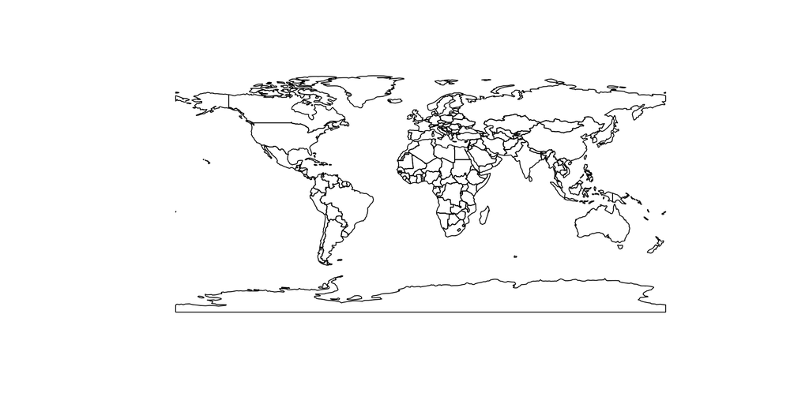

```r
# library(rnaturalearth)
world <- ne_countries() # world country outlines
plot(ne_countries()["geometry"])
```

## What in the world?

```r
kable(head(world))
```

| featurecla | scalerank | labelrank | sovereignt | sov_a3 | adm0_dif | level | type | tlc | admin | adm0_a3 | geou_dif | geounit | gu_a3 | su_dif | subunit | su_a3 | brk_diff | name | name_long | brk_a3 | brk_name | brk_group | abbrev | postal | formal_en | formal_fr | name_ciawf | note_adm0 | note_brk | … |
| --- | --- | --- | --- | --- | --- | --- | --- | --- | --- | --- | --- | --- | --- | --- | --- | --- | --- | --- | --- | --- | --- | --- | --- | --- | --- | --- | --- | --- | --- | --- |
| Admin-0 country | 1 | 6 | Fiji | FJI | 0 | 2 | Sovereign country | 1 | Fiji | FJI | 0 | Fiji | FJI | 0 | Fiji | FJI | 0 | Fiji | Fiji | FJI | Fiji | NA | Fiji | FJ | Republic of Fiji | NA | Fiji | NA | NA | … |
| Admin-0 country | 1 | 3 | United Republic of Tanzania | TZA | 0 | 2 | Sovereign country | 1 | United Republic of Tanzania | TZA | 0 | Tanzania | TZA | 0 | Tanzania | TZA | 0 | Tanzania | Tanzania | TZA | Tanzania | NA | Tanz. | TZ | United Republic of Tanzania | NA | Tanzania | NA | NA | … |
| Admin-0 country | 1 | 7 | Western Sahara | SAH | 0 | 2 | Indeterminate | 1 | Western Sahara | SAH | 0 | Western Sahara | SAH | 0 | Western Sahara | SAH | 1 | W. Sahara | Western Sahara | B28 | W. Sahara | NA | W. Sah. | WS | Sahrawi Arab Democratic Republic | NA | Western Sahara | NA | Self admin.; Claimed by Morocco | … |
| Admin-0 country | 1 | 2 | Canada | CAN | 0 | 2 | Sovereign country | 1 | Canada | CAN | 0 | Canada | CAN | 0 | Canada | CAN | 0 | Canada | Canada | CAN | Canada | NA | Can. | CA | Canada | NA | Canada | NA | NA | … |
| Admin-0 country | 1 | 2 | United States of America | US1 | 1 | 2 | Country | 1 | United States of America | USA | 0 | United States of America | USA | 0 | United States | USA | 0 | United States of America | United States | USA | United States | NA | U.S.A. | US | United States of America | NA | United States | NA | NA | … |
| Admin-0 country | 1 | 3 | Kazakhstan | KA1 | 1 | 1 | Sovereignty | 1 | Kazakhstan | KAZ | 0 | Kazakhstan | KAZ | 0 | Kazakhstan | KAZ | 0 | Kazakhstan | Kazakhstan | KAZ | Kazakhstan | NA | Kaz. | KZ | Republic of Kazakhstan | NA | Kazakhstan | NA | NA | … |

### What in the world? (cont’d)

```r
class(world)
```

```
[1] "sf"         "data.frame"
```

[figure not shown]

inside an sf object

### Quick Explanation for now

- An sf (“simple features”) object is:
  - a data.frame
  - with an extra geometry column
  - spatial metadata attached as attributes.
  - data.frame + geometry + CRS (coordinate reference system)
  - each row in our example is country
  - the geometry column contains the shape of that feature stored points, lines, or polygons

### ggplot is nicer and richer

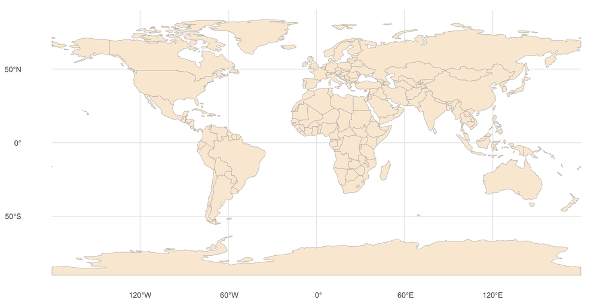

```r
ggplot() +
  geom_sf(data = world, fill = "antiquewhite", color = "gray70") +
  theme_minimal()
```

### Plotting Spatial Points

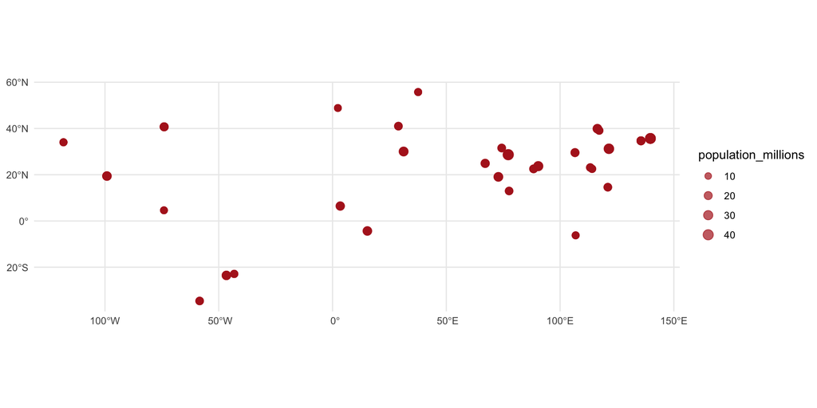

```r
ggplot() +
  geom_sf(data = urban_agglomerations, # from spData built in
          aes(size = population_millions),
          color = "firebrick", alpha = 0.7) +
  scale_size(range = c(1, 4)) +
  theme_minimal()
```

### What is urban_agglomerations?

```r
glimpse(urban_agglomerations)
```

```
Rows: 540
Columns: 10
$ index               <dbl> 1, 2, 3, 4, 5, 6, 7, 8, 9, 10, 11, 12, 13, 14, 15, 16, 17, 18, 19, 20, 21, 22, 23, 24, 25, 26, 27, 28, 29, 30, 31,…
$ year                <dbl> 1950, 1955, 1960, 1965, 1970, 1975, 1980, 1985, 1990, 1995, 2000, 2005, 2010, 2015, 2020, 2025, 2030, 2035, 1950, …
$ `rank\norder`       <dbl> 6, 5, 6, 5, 5, 6, 6, 7, 7, 10, 11, 11, 12, 12, 15, 18, 20, 21, 27, 28, 28, 28, 28, 25, 23, 21, 20, 19, 15, 13, 11,…
$ `country\ncode`     <dbl> 32, 32, 32, 32, 32, 32, 32, 32, 32, 32, 32, 32, 32, 32, 32, 32, 32, 32, 50, 50, 50, 50, 50, 50, 50, 50, 50, 50, 50…
$ country_or_area     <chr> "Argentina", "Argentina", "Argentina", "Argentina", "Argentina", "Argentina", "Argentina", "Argentina", "Argentina…
$ city_code           <dbl> 20058, 20058, 20058, 20058, 20058, 20058, 20058, 20058, 20058, 20058, 20058, 20058, 20058, 20058, 20058, 20058, 20…
$ urban_agglomeration <chr> "Buenos Aires", "Buenos Aires", "Buenos Aires", "Buenos Aires", "Buenos Aires", "Buenos Aires", "Buenos Aires", "B…
$ note                <dbl> 1, 1, 1, 1, 1, 1, 1, 1, 1, 1, 1, 1, 1, 1, 1, 1, 1, 1, 2, 2, 2, 2, 2, 2, 2, 2, 2, 2, 2, 2, 2, 2, 2, 2, 2, 2, NA, NA…
$ population_millions <dbl> 5.166140, 5.910271, 6.761837, 7.548511, 8.416170, 9.143219, 9.919781, 10.523442, 11.147566, 11.806407, 12.503871, …
$ geometry            <POINT [°]> POINT (-58.40037 -34.60508), POINT (-58.40037 -34.60508), POINT (-58.40037 -34.60508), POINT (-58.40037 -34.…
```

### Putting them together

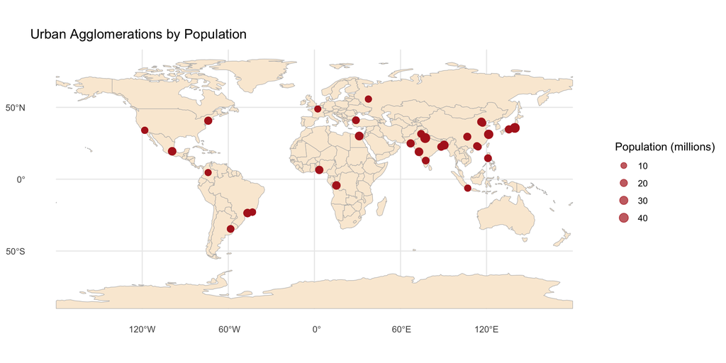

```r
ggplot() +
  geom_sf(data = world, fill = "antiquewhite", color = "gray70") +
  geom_sf(data = urban_agglomerations,
          aes(size = population_millions),  # pinmap style
          color = "firebrick", alpha = 0.7) +
  scale_size(range = c(1, 4)) +
  theme_minimal() +
  labs(
    title = "Urban Agglomerations by Population",
    size = "Population (millions)"
  )
```

### Putting things together (cont’d)

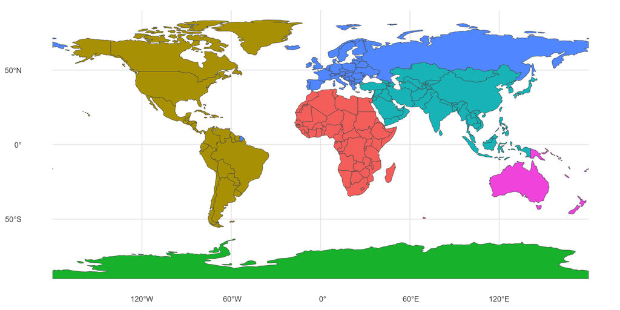

```r
ggplot() +
  geom_sf(data = world,
          aes(fill = region_un)) + # choropleth style
  theme_minimal() +
  theme(legend.position = "none")
```

### ggplot layers easily

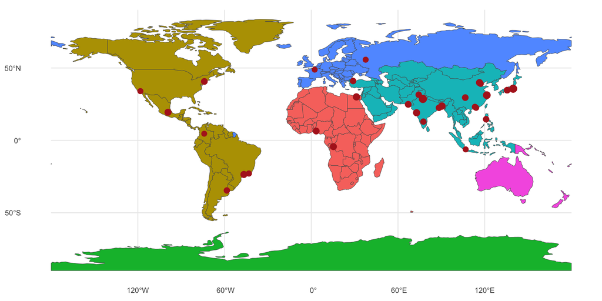

```r
ggplot() +
  geom_sf(data = world,
          aes(fill = region_un)) +
  geom_sf(data = urban_agglomerations,
          aes(size = population_millions),
          color = "firebrick", alpha = 0.7) +
  scale_size(range = c(1, 4)) +
  theme_minimal() +
  theme(legend.position = "none")
```

## Takeaways

- R has built in maps
- can be plotted in base R plot
- or ggplot (better)
- Underlying data is just a modified data frame with spatial features

## Activity

- Try extracting a part of the world, here is an example to get you started (result is on the next slide)

```r
world <- ne_countries()

east_asia <- world %>%
  filter(admin %in% c("China", "North Korea", "South Korea", "Japan", "Vietnam", "Myanmar", "Cambodia", "Thailand", "Laos",
                      "Taiwan", "Philippines"))

ggplot() +
  geom_sf(data = east_asia,
          aes(fill = log(pop_est))) +
          scale_fill_viridis_c(option = "plasma") +
          labs(fill = "log(Population)") +
          theme_minimal()
```

## Result

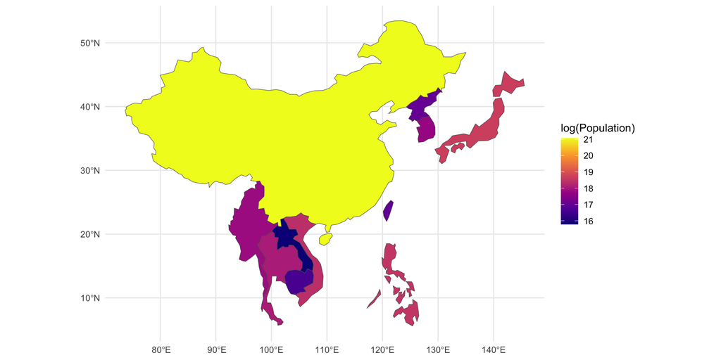

### External Example

- external data
- with XY (lat/lon) coordinates

```r
dispensary <- read_csv("https://raw.githubusercontent.com/lewv/sp25stats21/main/data/dispensary.csv")
glimpse(dispensary)
```

```
Rows: 688
Columns: 9
$ YEAR_START       <dbl> 2007, 2024, 2022, 2006, 2018, 2023, 2024, 2021, 2024, 2023, 2018, 2022, 2024, 2006, 2023, 2018, 2018, 2024, 2007, 202…
$ `BUSINESS NAME`  <chr> "CANNATOPIA GARDENS", "STANLEY ALLEY HOLDINGS LLC", "SAN PEDRO ISH LLC", "THE VAULT WOODLAND HILLS", "CLARMONTI CONSU…
$ `DBA NAME`       <chr> "CANNA SYLMAR", NA, "GOAT GLOBAL SOUTH LA", "MOTHER NATURE'S REMEDY", NA, "LA BREA COLLECTIVE", NA, "OFF THE CHARTS",…
$ `STREET ADDRESS` <chr> "13509 HUBBARD STREET", "6218 LANKERSHIM BLVD", "2522  S CENTRAL AVENUE    #2534", "22815   VENTURA BLVD", "945  E 10…
$ CITY             <chr> "SYLMAR", "NORTH HOLLYWOOD", "LOS ANGELES", "WOODLAND HILLS", "LOS ANGELES", "LOS ANGELES", "NORTH HILLS", "LOS ANGEL…
$ ZIP_CODE         <dbl> 91342, 91606, 90011, 91364, 90021, 90019, 91343, 90038, 90015, 91342, 90021, 91311, 91601, 90012, 90001, 90021, 90023…
$ longitude        <dbl> -118.4274, -118.3857, -118.2544, -118.6240, -118.2472, -118.3478, -118.4946, -118.3408, -118.2543, -118.4152, -118.24…
$ latitude         <dbl> 34.3099, 34.1839, 34.0190, 34.1659, 34.0333, 34.0482, 34.2222, 34.0836, 34.0342, 34.2927, 34.0257, 34.2457, 34.1605, …
$ COUNCIL_DISTRICT <dbl> 7, 2, 9, 3, 14, 10, 12, 5, 14, 7, 14, 12, 2, 14, 9, 14, 14, 8, 6, 13, 2, 4, 13, 14, 8, 5, 10, 9, 14, 14, 3, 14, 14, 7…
```

### Always check

```r
kable(head(dispensary))
```

| YEAR_START | BUSINESS NAME | DBA NAME | STREET ADDRESS | CITY | ZIP_CODE | longitude | latitude | COUNCIL_DISTRICT |
| --- | --- | --- | --- | --- | --- | --- | --- | --- |
| 2007 | CANNATOPIA GARDENS | CANNA SYLMAR | 13509 HUBBARD STREET | SYLMAR | 91342 | -118.4274 | 34.3099 | 7 |
| 2024 | STANLEY ALLEY HOLDINGS LLC | NA | 6218 LANKERSHIM BLVD | NORTH HOLLYWOOD | 91606 | -118.3857 | 34.1839 | 2 |
| 2022 | SAN PEDRO ISH LLC | GOAT GLOBAL SOUTH LA | 2522 S CENTRAL AVENUE #2534 | LOS ANGELES | 90011 | -118.2544 | 34.0190 | 9 |
| 2006 | THE VAULT WOODLAND HILLS | MOTHER NATURE’S REMEDY | 22815 VENTURA BLVD | WOODLAND HILLS | 91364 | -118.6240 | 34.1659 | 3 |
| 2018 | CLARMONTI CONSULTING LLC | NA | 945 E 10TH STREET # | LOS ANGELES | 90021 | -118.2472 | 34.0333 | 14 |
| 2023 | PEACE AND JOY LLC | LA BREA COLLECTIVE | 5057 W PICO BLVD | LOS ANGELES | 90019 | -118.3478 | 34.0482 | 10 |

### Some light data management

```r
dispensary <- dispensary %>%
  mutate(COUNCIL_DISTRICT = as.factor(COUNCIL_DISTRICT),
         YEAR_CLASS = cut(YEAR_START, c(-Inf, 2015, 2018, 2021, Inf),
                          labels = c("Pre-2016", "2016-2018", "2019-2021", "2022-present")))

# check
dispensary %>% group_by(YEAR_START, YEAR_CLASS) %>% tally()
```

```
# A tibble: 21 × 3
# Groups:   YEAR_START [21]
   YEAR_START YEAR_CLASS       n
        <dbl> <fct>        <int>
 1       2000 Pre-2016         1
 2       2005 Pre-2016         5
 3       2006 Pre-2016        70
 4       2007 Pre-2016        76
 5       2008 Pre-2016         1
 6       2009 Pre-2016         3
 7       2010 Pre-2016         1
 8       2011 Pre-2016         7
 9       2012 Pre-2016         4
10       2013 Pre-2016         1
11       2014 Pre-2016         7
12       2015 Pre-2016         1
13       2016 2016-2018        3
14       2017 2016-2018        2
15       2018 2016-2018      231
16       2019 2019-2021        6
17       2020 2019-2021        9
18       2021 2019-2021       56
19       2022 2022-present   121
20       2023 2022-present    75
21       2024 2022-present     8
```

### Simplest - use geom_point

The simplest type of map is a scatterplot with XY points plotted.

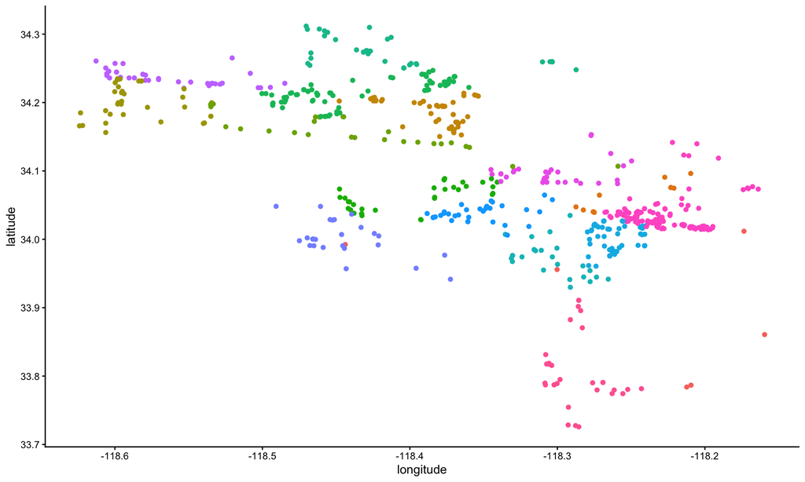

```r
ggplot(dispensary,
       aes(x = longitude, y = latitude, color =  COUNCIL_DISTRICT)) +
         geom_point() +
         theme_classic() +
         theme(legend.position = "none")
```

### geom_point with shape too

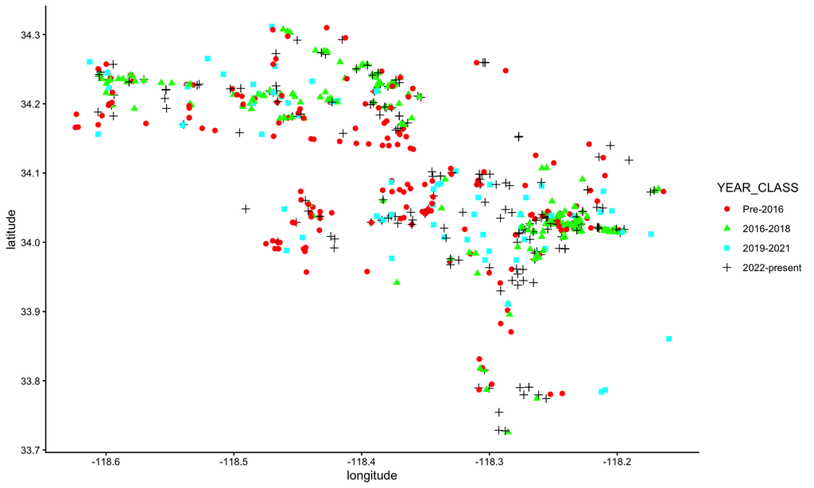

```r
ggplot(dispensary,
       aes(x = longitude, y = latitude, color =  YEAR_CLASS)) +
       geom_point(aes(shape=YEAR_CLASS), size=2) +
       scale_color_manual(values = c("red","green","cyan", "black")) +
       theme_classic()
```

### The `sf` package in R

- This package has tools for geographic data operations.
- It integrates with tidyverse easily (e.g., ggplot, lubridate)
- Uses the “simple features” standard for storing and manipulating spatial data.
- It can represent geometric objects like points, lines, polygons, and more complex objects like multipoints, multilines, and multipolygons.
- [See Wikipedia](https://en.wikipedia.org/wiki/Simple_Features) for more information about the simple features standard

### Some technical background about `sf` in R

- An sf object is a data frame where each row represents a spatial feature (such as a geographic location or area), and each column contains the attributes associated with that feature.
- One of the columns is a special list-column that contains geometry data in a format understood by the sf package
- The geometries in sf objects include POINT, LINESTRING, POLYGON, MULTIPOINT, MULTILINESTRING, MULTIPOLYGON and can represent almost any kind of spatial data.
- The sf package is designed work with dplyr, ggplot2, and other tidyverse packages
- The sf package allows import/export to other spatial data formats,

### Example - Convert a data frame with point coordinates

```r
# Convert the data frame to an sf object
points_sf <- st_as_sf(dispensary,
                      coords = c("longitude", "latitude"),
                      crs = 4326,
                      remove = FALSE)
```

- st_as_sf() converts a non-spatial feature object to spatial feature
- for point data, need the columns with the coordinates (x, y)
- crs is the coordinate reference sysem
- remove = FALSE keep the original variables

### What is a crs = 4326?

- CRS means “Coordinate Reference System”. The CRS defines how our 2D map relates to the corresponding locations on Earth.
- CRS states how the data is to be projected and how to interpret the coordinate system used in the data. It helps to align spatial data from different sources
- 4326 refers to a particular (there are many) CRS — WGS 84 (World Geodetic System 1984): This is the standard coordinate system used by the Global Positioning System (GPS)
- Knowing which CRS matters when we bring in additional spatial information from a different source

### CRS variant example

[figure not shown]

CRS variants

### Examine its structure

```r
str(points_sf)
```

```
sf [688 × 11] (S3: sf/tbl_df/tbl/data.frame)
 $ YEAR_START      : num [1:688] 2007 2024 2022 2006 2018 ...
 $ BUSINESS NAME   : chr [1:688] "CANNATOPIA GARDENS" "STANLEY ALLEY HOLDINGS LLC" "SAN PEDRO ISH LLC" "THE VAULT WOODLAND HILLS" ...
 $ DBA NAME        : chr [1:688] "CANNA SYLMAR" NA "GOAT GLOBAL SOUTH LA" "MOTHER NATURE'S REMEDY" ...
 $ STREET ADDRESS  : chr [1:688] "13509 HUBBARD STREET" "6218 LANKERSHIM BLVD" "2522  S CENTRAL AVENUE    #2534" "22815   VENTURA BLVD" ...
 $ CITY            : chr [1:688] "SYLMAR" "NORTH HOLLYWOOD" "LOS ANGELES" "WOODLAND HILLS" ...
 $ ZIP_CODE        : num [1:688] 91342 91606 90011 91364 90021 ...
 $ longitude       : num [1:688] -118 -118 -118 -119 -118 ...
 $ latitude        : num [1:688] 34.3 34.2 34 34.2 34 ...
 $ COUNCIL_DISTRICT: Factor w/ 16 levels "0","1","2","3",..: 8 3 10 4 15 11 13 6 15 8 ...
 $ YEAR_CLASS      : Factor w/ 4 levels "Pre-2016","2016-2018",..: 1 4 4 1 2 4 4 3 4 4 ...
 $ geometry        :sfc_POINT of length 688; first list element:  'XY' num [1:2] -118.4 34.3
 - attr(*, "sf_column")= chr "geometry"
 - attr(*, "agr")= Factor w/ 3 levels "constant","aggregate",..: NA NA NA NA NA NA NA NA NA NA
  ..- attr(*, "names")= chr [1:10] "YEAR_START" "BUSINESS NAME" "DBA NAME" "STREET ADDRESS" ...
```

### still ggplot, still ugly

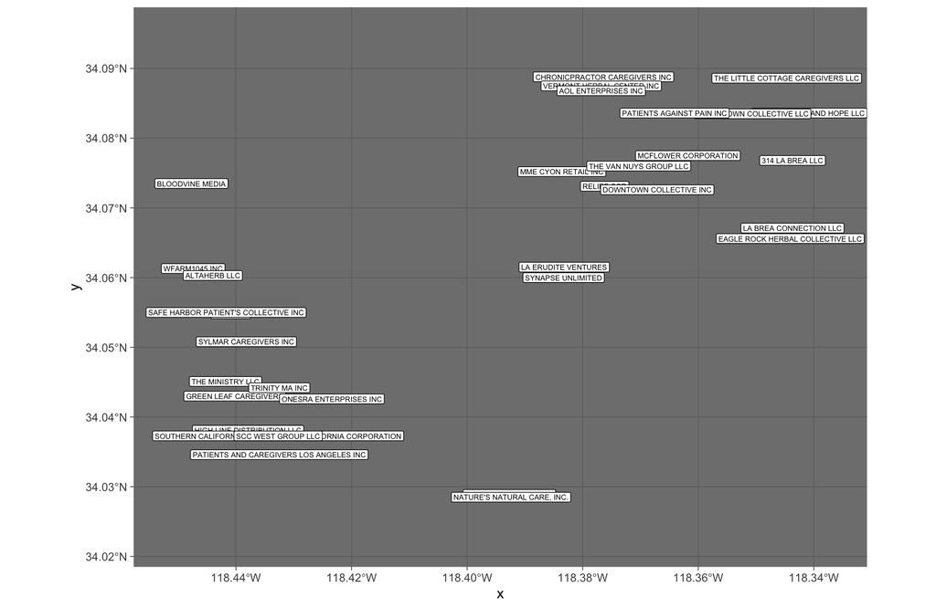

```r
dist_extent <- st_bbox(points_sf[points_sf$COUNCIL_DISTRICT == 5,])
dist5 <- points_sf[points_sf$COUNCIL_DISTRICT == 5,]

buffer_size <- 0.01

# Expand the bounding box by the buffer size
expanded_extent <- c(
  xmin = dist_extent$xmin - buffer_size,
  xmax = dist_extent$xmax + buffer_size,
  ymin = dist_extent$ymin - buffer_size,
  ymax = dist_extent$ymax + buffer_size
)

ggplot() +
  geom_sf(data = dist5) +
  geom_sf_label(data = dist5, aes(label = `BUSINESS NAME`), size = 2) +
  coord_sf(xlim = c(expanded_extent[1], expanded_extent[2]),
           ylim = c(expanded_extent[3], expanded_extent[4]),
           expand = FALSE) +
  theme_dark() +
  theme(legend.position = "none")
```

### Load a basemap (polygons)

- We don’t have a good reference for our points, they are just points or worse, labels.
- A basemap can provide administrative boundaries, roads etc. -This one, from the Los Angeles Times, is a geojson file of neighborhood boundaries.

```r
basemap <- st_read("LA_Times_Neighborhood_Boundaries.geojson")
```

### Examine the structure

str() can be helpful when you are trying understand new R objects

```r
str(basemap)
```

```
Classes 'sf' and 'data.frame':  114 obs. of  3 variables:
 $ OBJECTID: int  1 2 3 4 5 6 7 8 9 10 ...
 $ name    : chr  "Adams-Normandie" "Arleta" "Arlington Heights" "Atwater Village" ...
 $ geometry:sfc_MULTIPOLYGON of length 114; first list element: List of 1
  ..$ :List of 1
  .. ..$ : num [1:14, 1:2] -118 -118 -118 -118 -118 ...
  ..- attr(*, "class")= chr [1:3] "XY" "MULTIPOLYGON" "sfg"
 - attr(*, "sf_column")= chr "geometry"
 - attr(*, "agr")= Factor w/ 3 levels "constant","aggregate",..: NA NA
  ..- attr(*, "names")= chr [1:2] "OBJECTID" "name"
```

### Basemap

We can plot polygons as easily as points

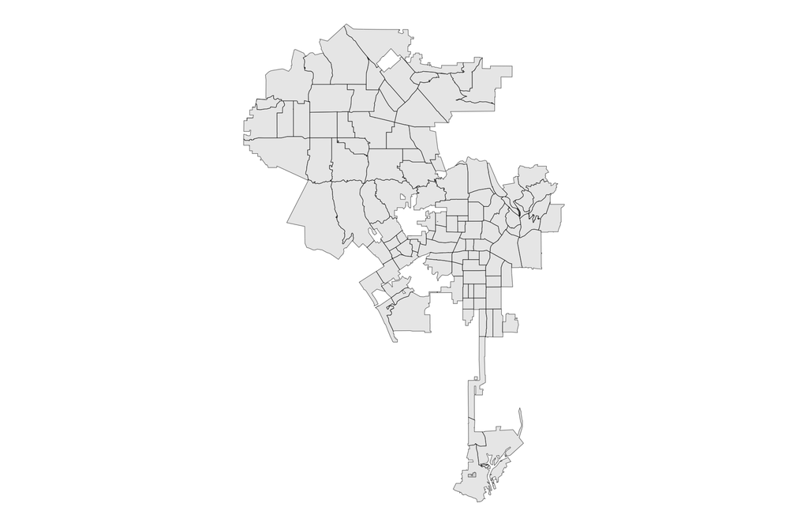

```r
ggplot() +
  geom_sf(data = basemap) +
  theme_void()
```

### Basemap modifies easily

With knowledge about the structure of the basemap, we can modify it using dplyr or base R functions:

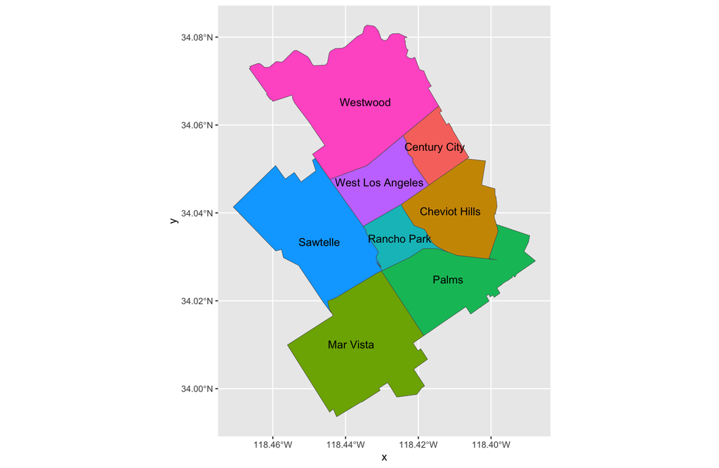

```r
westside <- basemap %>% filter(name %in% c("Westwood", "West Los Angeles", "Sawtelle",
"Palms", "Mar Vista", "Cheviot Hills", "Century City", "Rancho Park"))

ggplot(westside) +
  geom_sf(data = westside, aes(fill = as.factor(name))) +
  geom_sf_text(aes(label = name)) +
  theme(legend.position = "none")
```

### Apply it

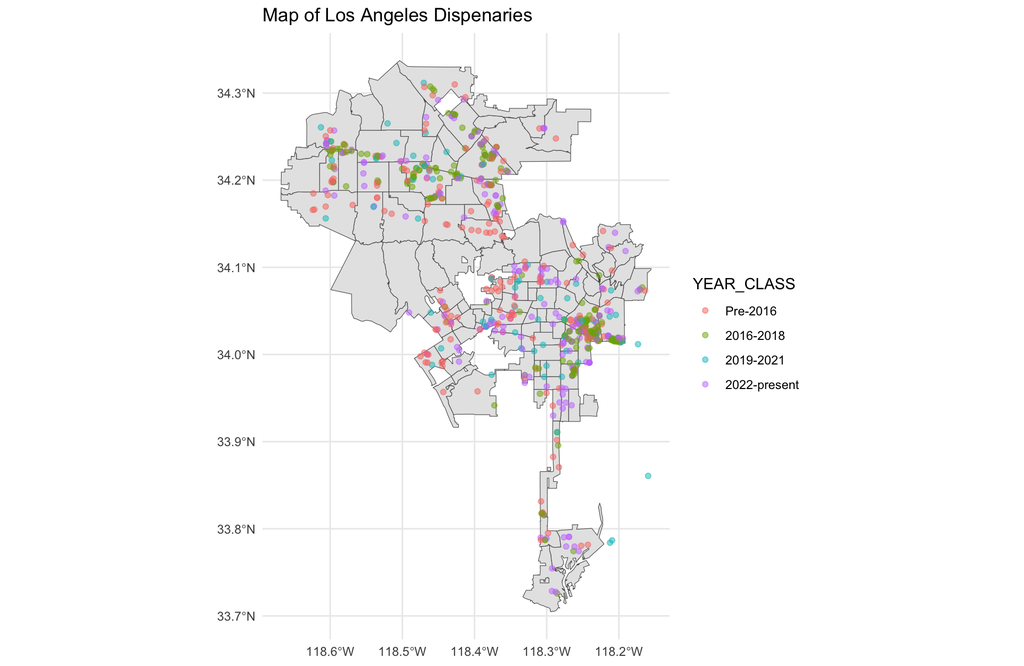

```r
ggplot(data = points_sf) +
  geom_sf(data = basemap) +
  geom_sf(aes(color = YEAR_CLASS), alpha = 0.5) +
  labs(title = "Map of Los Angeles Dispenaries") +
  theme_minimal()
```

### Also

```r
westside_extent <- st_bbox(westside)

ggplot(data = dist5) +
  geom_sf(data = westside, aes(fill = as.factor(name))) +
  geom_sf_label(data = westside, aes(label = name), size = 2, color = "black",
fill = "NA") +
  geom_sf_label(data = dist5, aes(label = `BUSINESS NAME`), size = 2, color = "black", fill = "green") +
  coord_sf(xlim = c(westside_extent$xmin, westside_extent$xmax-0.003),
           ylim = c(westside_extent$ymin, westside_extent$ymax),
           expand = FALSE) +
  labs(title = "Map of West Los Angeles Dispenaries") +
  theme_void()  +
  theme(legend.position = "none")
```

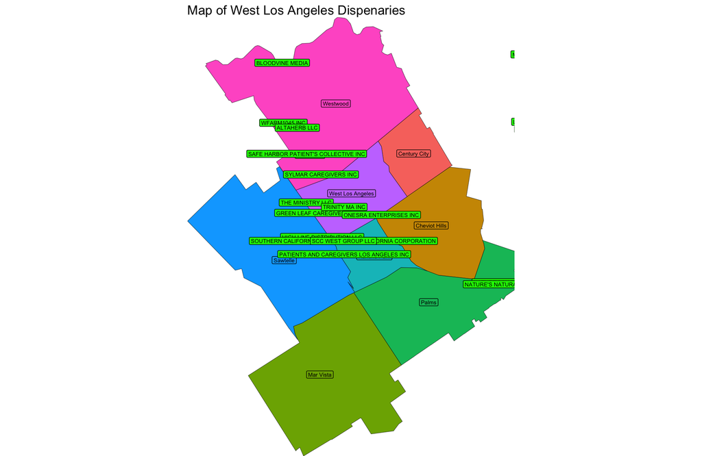

### On Geojson

- it is based on JSON making it easy to work with and to read.
- it is text-based and can be edited with any text editor.
- it defines geographical features like points, lines, and polygons, along with associated data.
- uses a specific CRS, the World Geodetic System 1984 (WGS84) and coordinates are listed as longitude, latitude.

### Finding basemaps

You can find these all over the internet. Be forewarned, some can be quite large and complicated.

[City of LA](https://geohub.lacity.org/)  
[County of LA](https://egis-lacounty.hub.arcgis.com/)  
[State of California](https://gis.data.ca.gov/)  
[US Census](https://www.census.gov/geographies/mapping-files/time-series/geo/carto-boundary-file.html)  
[NTS](https://prd-tnm.s3.amazonaws.com/index.html?prefix=StagedProducts/Tran/Shape/)  
[Arcgis](https://hub.arcgis.com/search)

### Other basemaps libraries

```r
library(maptiles) # extra maps
library(tidyterra) # extra geoms

basemap <- get_tiles(points_sf, provider = "OpenStreetMap")
```

### Open Street Map

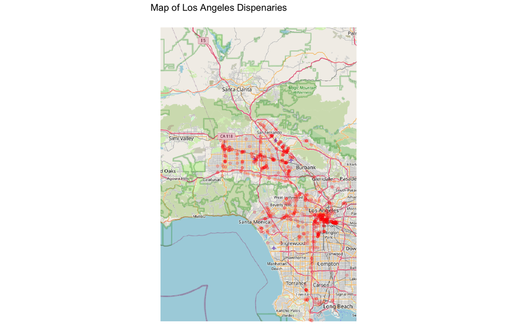

```r
ggplot(data = points_sf) +
  geom_spatraster_rgb(data = basemap) +
  geom_sf(data = points_sf, color = "red", alpha = 0.2) +
  labs(title = "Map of Los Angeles Dispenaries") +
  #coord_sf(xlim = c(-118.8, -118), ylim = c(33.6, 34.4)) +
  theme_void()
```

### Maps are layers… order matters

This will just cover the points, some throw errors, this one does not.

[figure not shown]

```r
ggplot(data = points_sf) +
  geom_sf(data = points_sf, color = "red", alpha = 0.2) +
  geom_spatraster_rgb(data = basemap) +
  labs(title = "Map of Los Angeles Dispenaries layers switched") +
  theme_void()
```

### Takeaways, Part 1

- A brief introduction to GIS in R, vocabulary etc.
- Libraries used
- Integration with ggplot
- Accessing external data and maps (basic)